# *Decision Tree: Supervised Machine Learning*

## *What is Decision Tree?*

*Decision Tree algorithm belongs to the family of supervised learning algorithms. Unlike other supervised learning algorithms, the decision tree algorithm can be used for solving regression and classification problems too.*

*The goal of using a Decision Tree is to create a training model that can use to predict the class or value of the target variable by learning simple decision rules inferred from prior data(training data).*

*A decision tree is a flowchart-like structure in which each internal node represents a test on a feature (e.g. whether a coin flip comes up heads or tails) , each leaf node represents a class label (decision taken after computing all features) and branches represent conjunctions of features that lead to those class labels. The paths from root to leaf represent classification rules.*

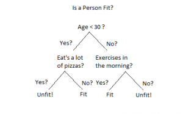

*Tree based learning algorithms are considered to be one of the best and mostly used supervised learning methods. Tree based methods empower predictive models with high accuracy, stability and ease of interpretation. Unlike linear models, they map non-linear relationships quite well. They are adaptable at solving any kind of problem at hand (classification or regression).*

- *Decision tress often mimic the human level thinking so its so simple to understand the data and make some good interpretations.*
- *Decision trees actually make you see the logic for the data to interpret(not like black box algorithms like SVM,NN,etc..)*

## *Terminologies Related to Decision Tree Algorithms*

- *Root Node:* *This node gets divided into different homogeneous nodes. It represents entire sample.*
- *Splitting:* *It is the process of splitting or dividing a node into two or more sub-nodes.*
- *Interior Nodes:* *They represent different tests on an attribute.*
- *Branches:* *They hold the outcomes of those tests.*
- *Leaf Nodes:* *When the nodes can’t be split further, they are called leaf nodes.*
- *Parent and Child Nodes:* *The node from where sub-nodes are created is called a parent node. And, the sub-nodes are called the child nodes.*

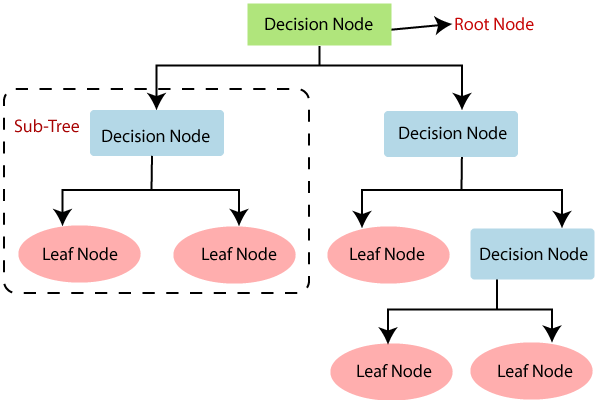

## *Advantages of Decision Tree Algorithms*

- *Easy to understand*
- *Requires minimum data cleaning*
- *No constraint on the data type*
- *Resistant to outliers, hence require little data preprocessing.*

## *Disadvantage of Decision Tree Algorithms*

- *Possibility of over fitting*
- *Need to be careful with parameter tuning.*
- *Can create biased learned trees if some classes dominate.*

## *How do Decision Trees work?*

*The decision of making strategic splits heavily affects a tree’s accuracy. The decision criteria are different for classification and regression trees.*

*Decision trees use multiple algorithms to decide to split a node into two or more sub-nodes. The creation of sub-nodes increases the homogeneity of resultant sub-nodes. In other words, we can say that the purity of the node increases with respect to the target variable. The decision tree splits the nodes on all available variables and then selects the split which results in most homogeneous sub-nodes.*

*The algorithm selection is also based on the type of target variables. Let us look at some algorithms used in Decision Trees:*

- *ID3* → *(extension of D3)*
- *C4.5* → *(successor of ID3)*
- *CART* → *(Classification And Regression Tree)*
- *CHAID* → *(Chi-square automatic interaction detection Performs multi-level splits when computing classification trees)*
- *MARS* → *(multivariate adaptive regression splines)*

*[Reference](https://medium.com/greyatom/decision-trees-a-simple-way-to-visualize-a-decision-dc506a403aeb)*

### *ID3 Algorithm*

*The ID3 (Iterative Dichotomiser) algorithm builds decision trees using a top-down greedy search approach through the space of possible branches with no backtracking. A greedy algorithm, as the name suggests, always makes the choice that seems to be the best at that moment.*

*Steps in ID3 algorithm:*

- *It begins with the original set S as the root node.*
- _On each iteration of the algorithm, it iterates through the very unused attribute of the set S and calculates *Entropy(H)* and *Information gain(IG)* of this attribute._
- *It then selects the attribute which has the smallest Entropy or Largest Information gain.*
- *The set S is then split by the selected attribute to produce a subset of the data.*
- *The algorithm continues to recur on each subset, considering only attributes never selected before.*

### *C4.5*

*This algorithm is the successor of the ID3 algorithm. This algorithm uses either Information gain or Gain ratio to decide upon the classifying attribute. It is a direct improvement from the ID3 algorithm as it can handle both continuous and missing attribute values.*

### *Classification and Regression Tree(CART)*

*It is a dynamic learning algorithm which can produce a regression tree as well as a classification tree depending upon the dependent variable.*

*[Reference](https://medium.com/datadriveninvestor/tree-algorithms-id3-c4-5-c5-0-and-cart-413387342164)*

## *Attribute Selection Measures*

*If the dataset consists of N attributes then deciding which attribute to place at the root or at different levels of the tree as internal nodes is a complicated step. By just randomly selecting any node to be the root can’t solve the issue. If we follow a random approach, it may give us bad results with low accuracy.*

*For solving this attribute selection problem, researchers worked and devised some solutions. They suggested using some criteria like :*

- *Entropy*
- *Information gain*
- *Gini index*
- *Gain Ratio*
- *Reduction in Variance*
- *Chi-Square*

*These criteria will calculate values for every attribute. The values are sorted, and attributes are placed in the tree by following the order i.e, the attribute with a high value(in case of information gain) is placed at the root.*

*While using Information Gain as a criterion, we assume attributes to be categorical, and for the Gini index, attributes are assumed to be continuous.*

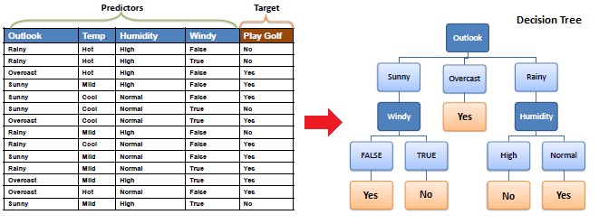

### *Entropy*

*Entropy is a measure of the randomness in the information being processed. The higher the entropy, the harder it is to draw any conclusions from that information. Flipping a coin is an example of an action that provides information that is random.*

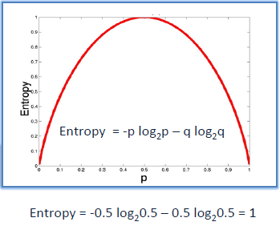

*From the above graph, it is quite evident that the entropy H(X) is zero when the probability is either 0 or 1. The Entropy is maximum when the probability is 0.5 because it projects perfect randomness in the data and there is no chance if perfectly determining the outcome.*

*ID3 follows the rule — A branch with an entropy of zero is a leaf node and A brach with entropy more than zero needs further splitting.*

*a) Entropy using the frequency table of one attribute:*

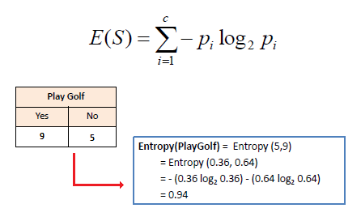

*b) Entropy using the frequency table of two attributes:*

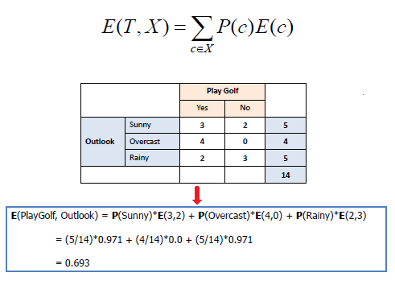

*where T→ Current state and X → Selected attribute*

### *Gini Index*

*You can understand the Gini index as a cost function used to evaluate splits in the dataset. It is calculated by subtracting the sum of the squared probabilities of each class from one. It favors larger partitions and easy to implement whereas information gain favors smaller partitions with distinct values.*

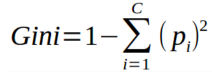

*Gini Index works with the categorical target variable “Success” or “Failure”. It performs only Binary splits.*

### *Difference between Entropy & Gini Index?*

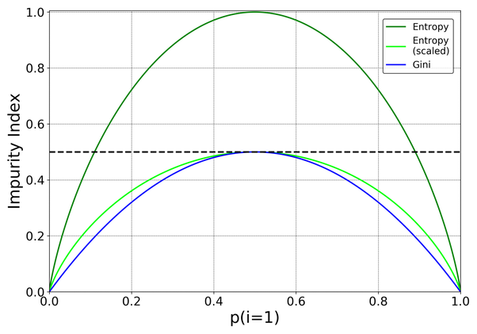

*One of the reasons why Gini is the default value in scikit-learn (Python library) is that entropy might be a little slower to compute (because it makes use of a logarithm).*

*[Reference](https://www.quora.com/What-is-difference-between-Gini-Impurity-and-Entropy-in-Decision-Tree)*

### *Information Gain*

*Information gain or IG is a statistical property that measures how well a given attribute separates the training examples according to their target classification. Constructing a decision tree is all about finding an attribute that returns the highest information gain and the smallest entropy.*

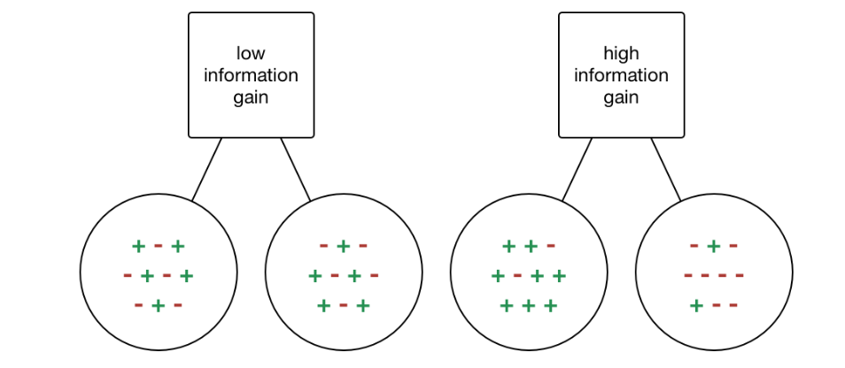

*Information gain is a decrease in entropy. It computes the difference between entropy before split and average entropy after split of the dataset based on given attribute values. ID3 (Iterative Dichotomiser) decision tree algorithm uses information gain.*

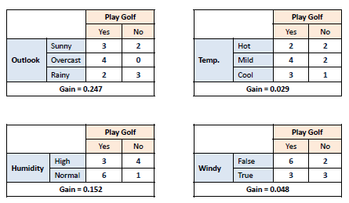

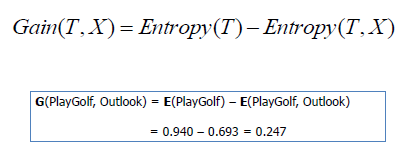

*Choose attribute with the largest information gain as the decision node, divide the dataset by its branches and repeat the same process on every branch. A branch with entropy of 0 is a leaf node and with Entropy>0 needs further splitting.*

### *Gain ratio*

*Information gain is biased towards choosing attributes with a large number of values as root nodes. It means it prefers the attribute with a large number of distinct values.*

*C4.5, an improvement of ID3, uses Gain ratio which is a modification of Information gain that reduces its bias and is usually the best option. Gain ratio overcomes the problem with information gain by taking into account the number of branches that would result before making the split. It corrects information gain by taking the intrinsic information of a split into account.*

*Let us consider if we have a dataset that has users and their movie genre preferences based on variables like gender, group of age, rating, blah, blah. With the help of information gain, you split at ‘Gender’ (assuming it has the highest information gain) and now the variables ‘Group of Age’ and ‘Rating’ could be equally important and with the help of gain ratio, it will penalize a variable with more distinct values which will help us decide the split at the next level.*

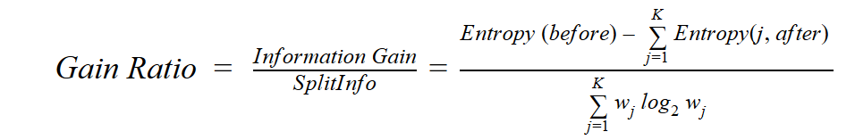

*Where “before” is the dataset before the split, K is the number of subsets generated by the split, and (j, after) is subset j after the split.*

### *Reduction in Variance*

*Reduction in variance is an algorithm used for continuous target variables (regression problems). This algorithm uses the standard formula of variance to choose the best split. The split with lower variance is selected as the criteria to split the population:*

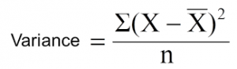

*Above X-bar is the mean of the values, X is actual and n is the number of values.*

*Steps to calculate Variance:*

- *Calculate variance for each node.*
- *Calculate variance for each split as the weighted average of each node variance.*

### *Chi-Square*

*The acronym CHAID stands for Chi-squared Automatic Interaction Detector. It is one of the oldest tree classification methods. It finds out the statistical significance between the differences between sub-nodes and parent node. We measure it by the sum of squares of standardized differences between observed and expected frequencies of the target variable.*

*It works with the categorical target variable “Success” or “Failure”. It can perform two or more splits. Higher the value of Chi-Square higher the statistical significance of differences between sub-node and Parent node.*

*It generates a tree called CHAID (Chi-square Automatic Interaction Detector).*

*Mathematically, Chi-squared is represented as:*

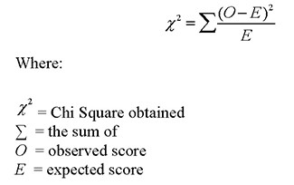

*Steps to Calculate Chi-square for a split:*

- *Calculate Chi-square for an individual node by calculating the deviation for Success and Failure both*
- *Calculated Chi-square of Split using Sum of all Chi-square of success and Failure of each node of the split*

*[Important Reference](https://towardsdatascience.com/the-simple-math-behind-3-decision-tree-splitting-criterions-85d4de2a75fe)*

## *How to avoid/counter Overfitting in Decision Trees?*

*The common problem with Decision trees, especially having a table full of columns, they fit a lot. Sometimes it looks like the tree memorized the training data set. If there is no limit set on a decision tree, it will give you 100% accuracy on the training data set because in the worse case it will end up making 1 leaf for each observation. Thus this affects the accuracy when predicting samples that are not part of the training set.*

*Here are two ways to remove overfitting:*

- *Pruning Decision Trees*
- *Random Forest*

### *Pruning Decision Trees*

*The splitting process results in fully grown trees until the stopping criteria are reached. But, the fully grown tree is likely to overfit the data, leading to poor accuracy on unseen data.*

*n pruning, you trim off the branches of the tree, i.e., remove the decision nodes starting from the leaf node such that the overall accuracy is not disturbed. This is done by segregating the actual training set into two sets: training data set, D and validation data set, V. Prepare the decision tree using the segregated training data set, D. Then continue trimming the tree accordingly to optimize the accuracy of the validation data set, V.*

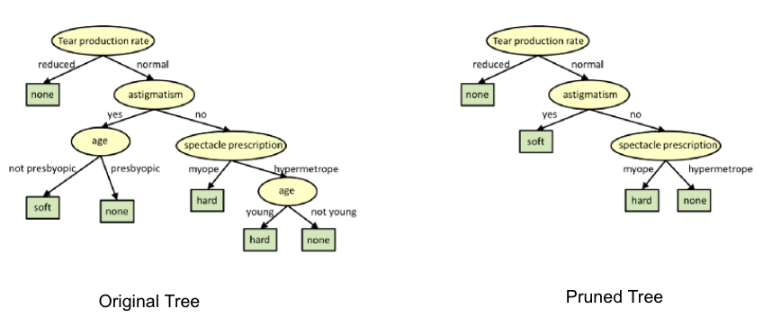

### *Random Forest*

*Random Forest is an example of ensemble learning, in which we combine multiple machine learning algorithms to obtain better predictive performance.*

*Why the name “Random”?*

*Two key concepts that give it the name random:*

- *A random sampling of training data set when building trees.*
- *Random subsets of features considered when splitting nodes.*

*A technique known as bagging is used to create an ensemble of trees where multiple training sets are generated with replacement.*

*In the bagging technique, a data set is divided into N samples using randomized sampling. Then, using a single learning algorithm a model is built on all samples. Later, the resultant predictions are combined using voting or averaging in parallel.*

## *Which is better Linear or tree-based models?*

*Well, it depends on the kind of problem you are solving.*

- *If the relationship between dependent & independent variables is well approximated by a linear model, linear regression will outperform the tree-based model.*
- *If there is a high non-linearity & complex relationship between dependent & independent variables, a tree model will outperform a classical regression method.*
- *If you need to build a model that is easy to explain to people, a decision tree model will always do better than a linear model. Decision tree models are even simpler to interpret than linear regression!*

## *Optimizing the Decision Tree Classifier*

```
DecisionTreeClassifier(class_weight=None, criterion='entropy', max_depth=None,
            max_features=None, max_leaf_nodes=None,
            min_impurity_decrease=0.0, min_impurity_split=None,
            min_samples_leaf=1, min_samples_split=2,
            min_weight_fraction_leaf=0.0, presort=False, random_state=None,
            splitter='best')
```

*[Reference](https://medium.com/@mohtedibf/indepth-parameter-tuning-for-decision-tree-6753118a03c3)*

```python
# Packages / libraries

import os #provides functions for interacting with the operating system

import numpy as np
import pandas as pd
from matplotlib import pyplot as plt
import seaborn as sns

%matplotlib inline

import warnings
warnings.filterwarnings('ignore')
```

```python
dataset_classification = pd.read_csv(r"C:\Users\PiyushSin\Desktop\datasets\bill_authentication.csv")
dataset_regression = pd.read_csv(r'C:\Users\PiyushSin\Desktop\datasets\petrol_consumption.csv')
```

## *Modelling Descision Tree Classifier*

```python
dataset_classification.head()
```

|  | Variance | Skewness | Curtosis | Entropy | Class |
| --- | --- | --- | --- | --- | --- |
| 0 | 3.62160 | 8.6661 | -2.8073 | -0.44699 | 0 |
| 1 | 4.54590 | 8.1674 | -2.4586 | -1.46210 | 0 |
| 2 | 3.86600 | -2.6383 | 1.9242 | 0.10645 | 0 |
| 3 | 3.45660 | 9.5228 | -4.0112 | -3.59440 | 0 |
| 4 | 0.32924 | -4.4552 | 4.5718 | -0.98880 | 0 |

```python
dataset_classification.shape
```

```
(1372, 5)
```

```python
X = dataset_classification.drop('Class', axis=1)
y = dataset_classification['Class']
```

```python
from sklearn.model_selection import train_test_split

X_train, X_test, y_train, y_test = train_test_split(X, y, test_size=0.20)
```

```python
# Importing Model Library
from sklearn.tree import DecisionTreeClassifier

classifier = DecisionTreeClassifier(criterion='gini',
    splitter='best',
    max_depth=None,
    min_samples_split=2,
    min_samples_leaf=1,
    random_state=21)
```

```python
classifier.fit(X_train, y_train)
```

```
DecisionTreeClassifier(random_state=21)
```

```python
y_pred = classifier.predict(X_test)
```

```python
from sklearn.metrics import classification_report, confusion_matrix

print(confusion_matrix(y_test, y_pred))
print(classification_report(y_test, y_pred))
```

```
[[148   2]
 [  3 122]]
              precision    recall  f1-score   support

           0       0.98      0.99      0.98       150
           1       0.98      0.98      0.98       125

    accuracy                           0.98       275
   macro avg       0.98      0.98      0.98       275
weighted avg       0.98      0.98      0.98       275
```

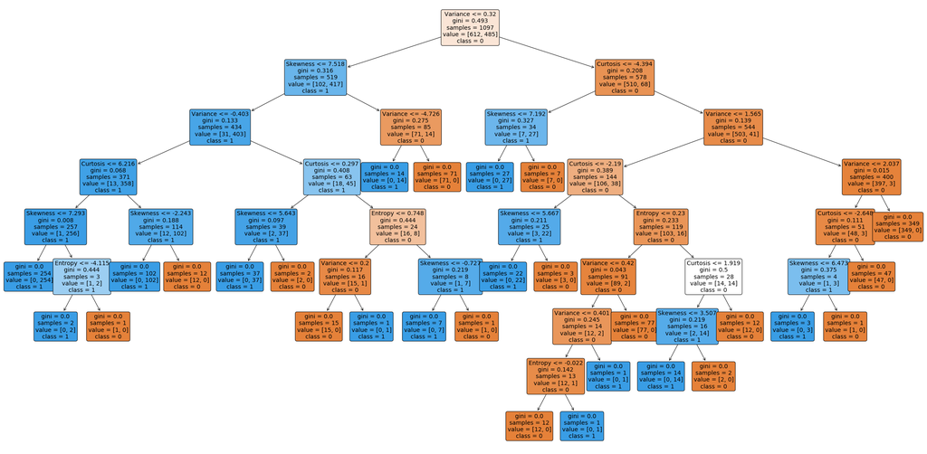

```python
# Plotting Decision Tree
from sklearn.tree import plot_tree

plt.figure(figsize=(40,20))
graph = plot_tree(classifier,
              feature_names=X.columns,
              class_names=['0','1'],
              filled=True,
              rounded=True,
              fontsize=14)
```

```python
# Exporting the decision tree
from sklearn.tree import export_graphviz

export_graphviz(classifier, out_file = 'classifier.dot')
```

## *Modelling Descision Tree Regressor*

*Regression trees work on the principal of reduction in variance/MSE, the output is predicted by taking mean of values in the leaf node.* _[Reference](https://www.python-course.eu/Regression_Trees.php)_

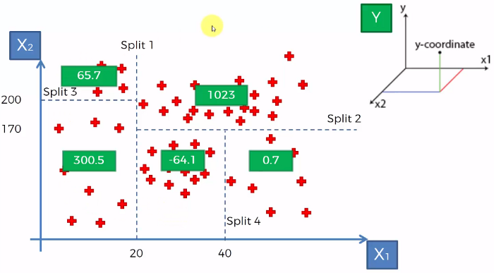

```python
dataset_regression.head()
```

|  | Petrol_tax | Average_income | Paved_Highways | Population_Driver_licence(%) | Petrol_Consumption |
| --- | --- | --- | --- | --- | --- |
| 0 | 9.0 | 3571 | 1976 | 0.525 | 541 |
| 1 | 9.0 | 4092 | 1250 | 0.572 | 524 |
| 2 | 9.0 | 3865 | 1586 | 0.580 | 561 |
| 3 | 7.5 | 4870 | 2351 | 0.529 | 414 |
| 4 | 8.0 | 4399 | 431 | 0.544 | 410 |

```python
X = dataset_regression.drop('Petrol_Consumption', axis=1)
y = dataset_regression['Petrol_Consumption']
```

```python
from sklearn.model_selection import train_test_split

X_train, X_test, y_train, y_test = train_test_split(X, y, test_size=0.20, random_state=0)
```

```python
# Importing Model Library
from sklearn.tree import DecisionTreeRegressor

regressor = DecisionTreeRegressor(criterion='mse',
                                   max_depth=None,
                                   min_samples_leaf=1,
                                   random_state=0,
                                   splitter='best')
```

```python
regressor.fit(X_train, y_train)
```

```
DecisionTreeRegressor(random_state=0)
```

```python
y_pred = regressor.predict(X_test)
```

```python
df=pd.DataFrame({'Actual':y_test, 'Predicted':y_pred})
df
```

|  | Actual | Predicted |
| --- | --- | --- |
| 29 | 534 | 547.0 |
| 4 | 410 | 414.0 |
| 26 | 577 | 574.0 |
| 30 | 571 | 554.0 |
| 32 | 577 | 631.0 |
| 37 | 704 | 644.0 |
| 34 | 487 | 628.0 |
| 40 | 587 | 540.0 |
| 7 | 467 | 414.0 |
| 10 | 580 | 464.0 |

```python
# Evaluating
from sklearn import metrics

print('Mean Absolute Error:', metrics.mean_absolute_error(y_test, y_pred))
print('Mean Squared Error:', metrics.mean_squared_error(y_test, y_pred))
print('Root Mean Squared Error:', np.sqrt(metrics.mean_squared_error(y_test, y_pred)))
```

```
Mean Absolute Error: 50.8
Mean Squared Error: 4535.4
Root Mean Squared Error: 67.34537846058926
```

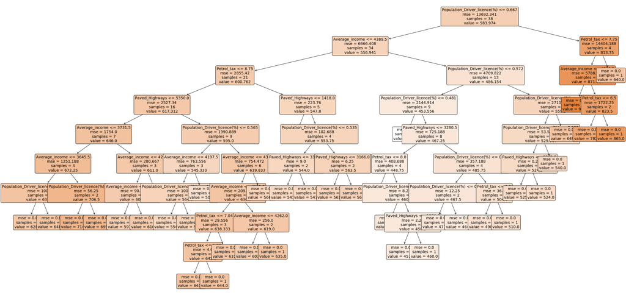

```python
# Plotting Decision Tree
from sklearn.tree import plot_tree

plt.figure(figsize=(40,20))
graph = plot_tree(regressor,
              feature_names=X.columns,
              class_names=['Cost'],
              filled=True,
              rounded=True,
              fontsize=14)
```

```python
# Visualising the Training set results
#from matplotlib.colors import ListedColormap
#X_set, y_set = X_train, y_train
#X1, X2 = np.meshgrid(np.arange(start = X_set[:, 0].min() - 1, stop = X_set[:, 0].max() + 1, step = 0.01),
#                     np.arange(start = X_set[:, 1].min() - 1, stop = X_set[:, 1].max() + 1, step = 0.01))
#plt.contourf(X1, X2, classifier.predict(np.array([X1.ravel(), X2.ravel()]).T).reshape(X1.shape),
#             alpha = 0.75, cmap = ListedColormap(('red', 'green')))
#plt.xlim(X1.min(), X1.max())
#plt.ylim(X2.min(), X2.max())
#for i, j in enumerate(np.unique(y_set)):
#    plt.scatter(X_set[y_set == j, 0], X_set[y_set == j, 1],
#                c = ListedColormap(('black', 'yellow'))(i), label = j)
#plt.title('Decision Tree Classification (Training set)')
#plt.legend()
#plt.show()
#
```

```python
# Feature scaling is not necessary in DT however it helps in visualization,
# OHE is also not required for DT as it can handle categorical data, instead we can use target encoing if needed.
```

## *Multiclass Classification*

```python
from sklearn import datasets
```

```python
# load the iris datasets
dataset = datasets.load_wine()

X = pd.DataFrame(dataset.data)
X.columns = dataset.feature_names
y = dataset.target

X_train, X_test, y_train, y_test = train_test_split(X, y, test_size=0.25)
```

```python
X_train.head()
```

|  | alcohol | malic_acid | ash | alcalinity_of_ash | magnesium | total_phenols | flavanoids | nonflavanoid_phenols | proanthocyanins | color_intensity | hue | od280/od315_of_diluted_wines | proline |
| --- | --- | --- | --- | --- | --- | --- | --- | --- | --- | --- | --- | --- | --- |
| 33 | 13.76 | 1.53 | 2.70 | 19.5 | 132.0 | 2.95 | 2.74 | 0.50 | 1.35 | 5.40 | 1.25 | 3.00 | 1235.0 |
| 63 | 12.37 | 1.13 | 2.16 | 19.0 | 87.0 | 3.50 | 3.10 | 0.19 | 1.87 | 4.45 | 1.22 | 2.87 | 420.0 |
| 175 | 13.27 | 4.28 | 2.26 | 20.0 | 120.0 | 1.59 | 0.69 | 0.43 | 1.35 | 10.20 | 0.59 | 1.56 | 835.0 |
| 75 | 11.66 | 1.88 | 1.92 | 16.0 | 97.0 | 1.61 | 1.57 | 0.34 | 1.15 | 3.80 | 1.23 | 2.14 | 428.0 |
| 52 | 13.82 | 1.75 | 2.42 | 14.0 | 111.0 | 3.88 | 3.74 | 0.32 | 1.87 | 7.05 | 1.01 | 3.26 | 1190.0 |

```python
# fit a tree.DecisionTreeClassifier() model to the data
model = DecisionTreeClassifier()
model.fit(X_train, y_train)

# make predictions
expected_y  = y_test
predicted_y = model.predict(X_test)
```

```python
# summarize the fit of the model
print(classification_report(expected_y, predicted_y, target_names=dataset.target_names))
```

```
              precision    recall  f1-score   support

     class_0       0.88      0.82      0.85        17
     class_1       0.82      0.82      0.82        17
     class_2       0.92      1.00      0.96        11

    accuracy                           0.87        45
   macro avg       0.87      0.88      0.88        45
weighted avg       0.87      0.87      0.87        45
```

```python
print(confusion_matrix(expected_y, predicted_y))
```

```
[[14  3  0]
 [ 2 14  1]
 [ 0  0 11]]
```